# Contribuições Financeiras para Campanhas Presidenciais por Estado(Califórnia) por Fabricio Bento

## Analise duas variáveis

### Fale sobre as relações que você observou nessa parte da investigação. Como a informação de interesse variam com os outros recursos no dataset?

Devido ao dataset ser constituído de muitas variáveis que não possuem uma boa correlação entre elas, separei-as em grupos e analisei a relação entre a quantidade de contribuições e o valor arrecadado, no caso do grupo dos candidatos, mostra o gráfico linear na relação quantidade vs valor.

### Você observou alguma relação de interesse nas outras informações (não na informação principal)?

Na maioria dos grupos testados a correlação entre quantidade x valor, apresentou resultado satisfatórios a maior acima de 0.90, exceto no grupo de doadores, onde apresentou a pior correlação, aproximadamente 0.20

### Qual o relacionamento mais forte que você encontrou?

O relacionamento mais forte foi de quantidade x valor do grupo cidades, aproximadamente 0.96.

## Gráficos multivariaveis

Utilizando multivariaveis, podemos fazer uma abordagem mais especifica, como por exemplo, descobrir a distribuição das contribuições realizadas por aposentado e desempregados, a distribuição de votos dos candidatos nas cidades com maior contribuição ou uma melhor analise das contribuições com valor negativo.

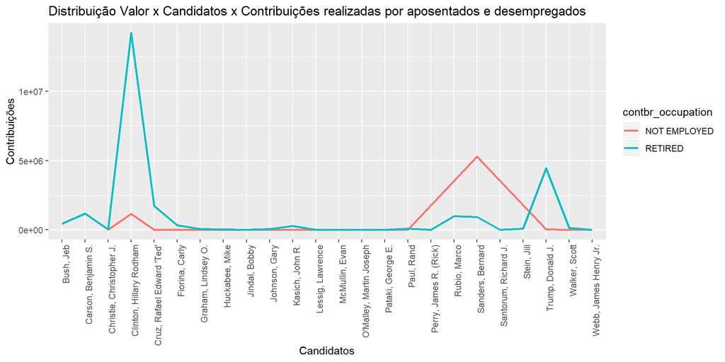

A candidata Clinton, Hillary Rodham recebeu o maior valor de contribuições dos aposentados, e o candidato Sanders, Bernard nos contribuições realizada por desempregados. A distribuição das contribuições dos 6 candidatos com maior valor recebido nas 6 cidades com maior contribuição.

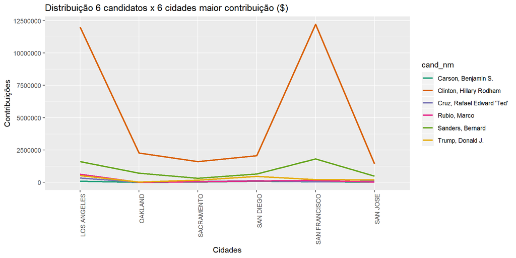

Uma ideia para visualizar o gráfico acima é usando jitter:

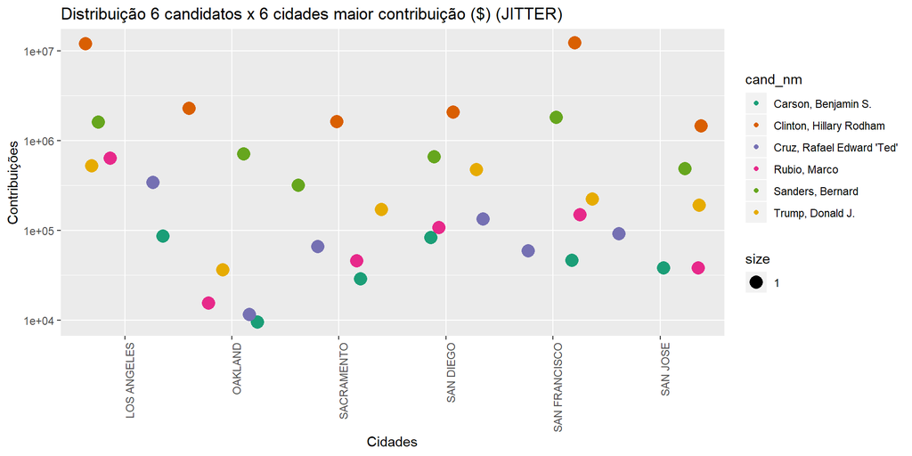

Aproveitando os 6 candidatos e as 6 cidades, vamos verificar a distribuições das contribuições dos aposentados e desempregados.

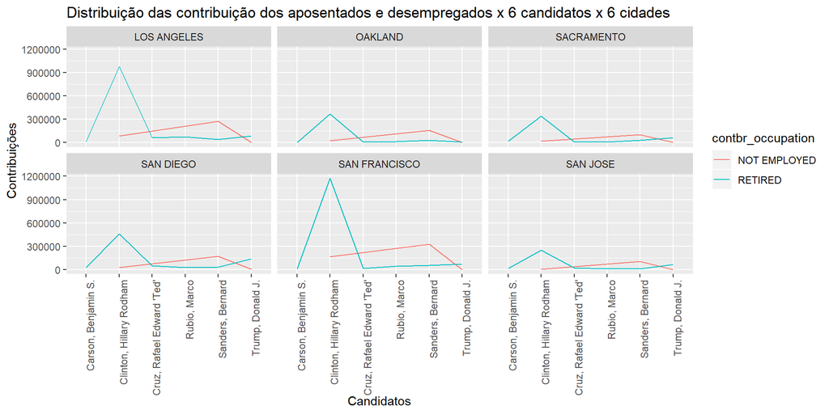

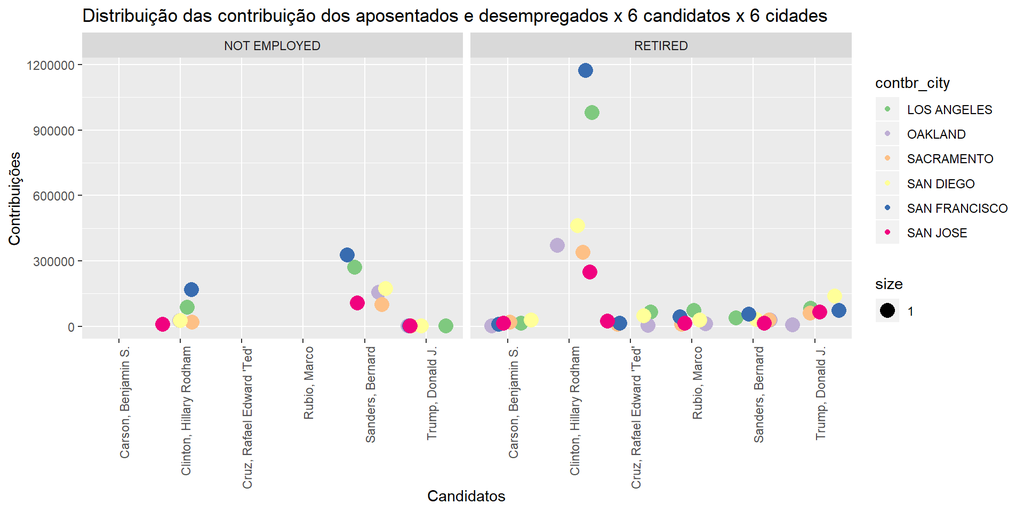

Podemos analisar a corrida das contribuições entre os 3 candidatos com maiores contribuições no mês de set/16, que como já verificamos é o mês com maior número de contribuição em dinheiro.

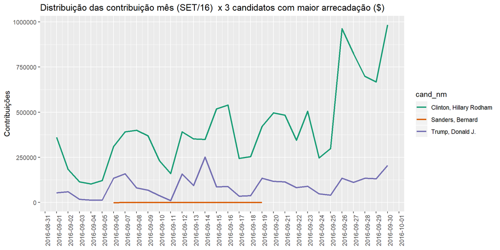

Podemos usar a mesma técnica acima para exploramos as contribuições negativas, em especifico o candidato Rubio, Marco que recebeu o maior número de contribuições negativas.

[output not shown]

```r
ca.ca_rubio <- tibble(ca.rubio, ca.rubio$contb_receipt_dt) %>%
  group_by(month = floor_date(ca.rubio$contb_receipt_dt, unit = 'month')) %>%
  dplyr::summarize(total = sum(ca.rubio$total),
                   n = n())
```

Primeiro vamos descobrir quando as doações negativas ocorreram.

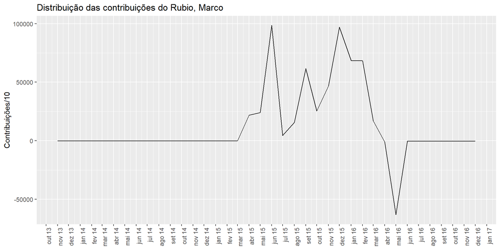

Descobrimos que foi no mês de maio, vamos visualizar esse mês para ver a movimentação nos dias.

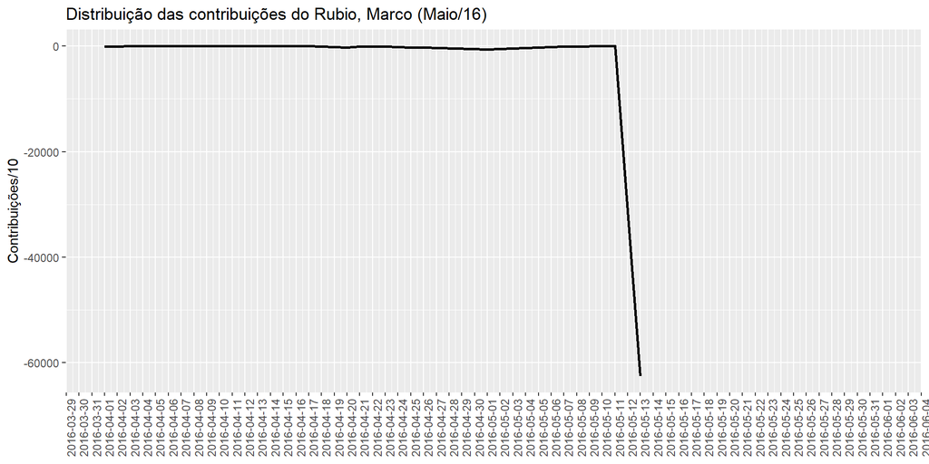

No dia 13/05/16 foram realizado o pedido de reembolso.

```r
ca.rubio_desc_maio <- subset(ca, ca$contb_receipt_dt== as.Date('2016-05-13') & ca$cand_nm=='Rubio, Marco')
summary(ca.rubio_desc_maio)
```

```
##       cmte_id         cand_id                         cand_nm
##  C00458844:325   P60006723:325   Rubio, Marco             :325
##  C00500587:  0   P00003392:  0   Bush, Jeb                :  0
##  C00573519:  0   P20002671:  0   Carson, Benjamin S.      :  0
##  C00574624:  0   P20002721:  0   Christie, Christopher J. :  0
##  C00575449:  0   P20003281:  0   Clinton, Hillary Rodham  :  0
##  C00575795:  0   P20003984:  0   Cruz, Rafael Edward 'Ted':  0
##  (Other)  :  0   (Other)  :  0   (Other)                  :  0
##                    contbr_nm            contbr_city  contbr_st
##  ABAJIAN, TED           :  1   LOS ANGELES    : 36   CA:325
##  ABERS, ANNA            :  1   BEVERLY HILLS  : 24
##  AHMANSON, ROBERTA GREEN:  1   PASADENA       : 19
##  ALDATZ, TINA           :  1   MALIBU         : 12
##  ALDEN, KATHERINE H.    :  1   RANCHO SANTA FE: 10
##  ALEXANDER, NEIL        :  1   PALO ALTO      :  9
##  (Other)                :319   (Other)        :215
##    contbr_zip          contbr_employer          contbr_occupation
##  90210  : 17                   :325                      :325
##  90265  : 13   ''RETIRED''     :  0    ''RETIRED''       :  0
##  91105  : 12   'K' LINE AMERICA:  0    'CALL CENTER AGENT:  0
##  92067  : 11   'SELF'          :  0    'NOT EMPLOYED'    :  0
##  90049  :  9   -               :  0    -                 :  0
##  90067  :  9   --              :  0    --                :  0
##  (Other):254   (Other)         :  0    (Other)           :  0
##  contb_receipt_amt contb_receipt_dt
##  Min.   :-2700     Min.   :2016-05-13
##  1st Qu.:-2700     1st Qu.:2016-05-13
##  Median :-2700     Median :2016-05-13
##  Mean   :-1923     Mean   :2016-05-13
##  3rd Qu.: -830     3rd Qu.:2016-05-13
##  Max.   :  -10     Max.   :2016-05-13
##
##                                                            receipt_desc
##  Refund                                                          :325
##                                                                  :  0
##  * EARMARKED CONTRIBUTION: SEE BELOW REATTRIBUTION/REFUND PENDING:  0
##  * REATTRIBUTED FROM ERIC UHRANE                                 :  0
##  * REATTRIBUTED FROM JENNIFER WILLIAMS                           :  0
##  * REATTRIBUTED FROM JOHN CAWLEY                                 :  0
##  (Other)                                                         :  0
##  memo_cd                        memo_text    form_tp       file_num
##   :325                               :325   SA17A:  0   Min.   :1079053
##  X:  0   $0.02 REFUNDED ON 10/21/2016:  0   SA18 :  0   1st Qu.:1079053
##          $0.12 REFUNDED ON 10/24/2016:  0   SB28A:325   Median :1079053
##          $0.14 REFUNDED ON 10/24/2016:  0               Mean   :1079053
##          $0.15 REFUNDED ON 10/24/2016:  0               3rd Qu.:1079053
##          $0.24 REFUNDED ON 10/24/2016:  0               Max.   :1079053
##          (Other)                     :  0
##        tran_id    election_tp
##  SB28A.6468:  1        :  0
##  SB28A.6474:  1   G2016:325
##  SB28A.6508:  1   O2016:  0
##  SB28A.6520:  1   P2016:  0
##  SB28A.6522:  1   P2020:  0
##  SB28A.6526:  1
##  (Other)   :319
```

A distribuição dos reembolsos realizado no dia 13/05/16, utilizado jitter e alpha.

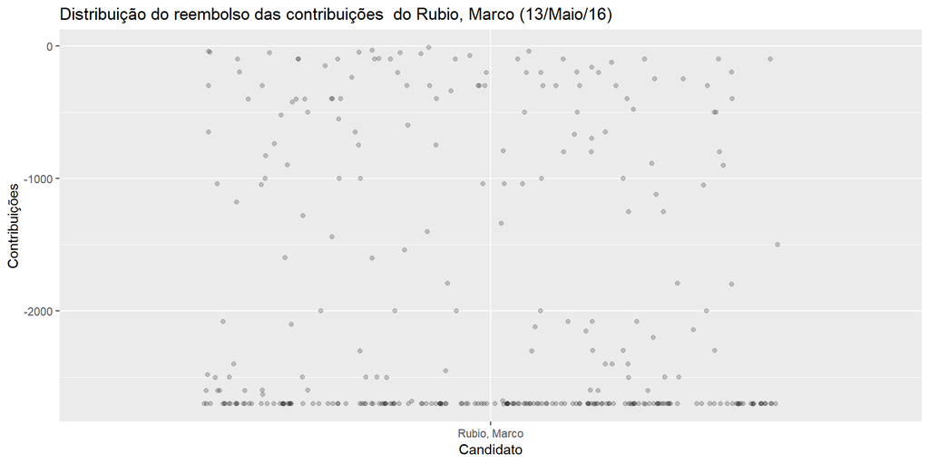

## Analise multi variáveis

### Fale sobre alguns dos relacionamentos que você observou nesta parte da investigação. Havia recursos que se fortaleciam em termos de olhar para seu (s) recurso (s) de interesse?

A distribuição das contribuições dos aposentados e desempregados, onde a candidata Clinton, Hillary Rodham recebeu o maior valor de contribuições dos aposentados, e o candidato Sanders, Bernard nos contribuições realizada por desempregados. Também a analise feitas das contribuições negativas, onde foi possível acompanhar as contribuições do candidato Rubio, Marco e descobrir o período e a quantidade de reembolso.

### Houve interações interessantes ou surpreendentes entre os recursos?

Candidatos, cidade, valor, e ocupação mostraram informações bem relevantes.

## Gráficos finais e resumo

### Gráfico 1

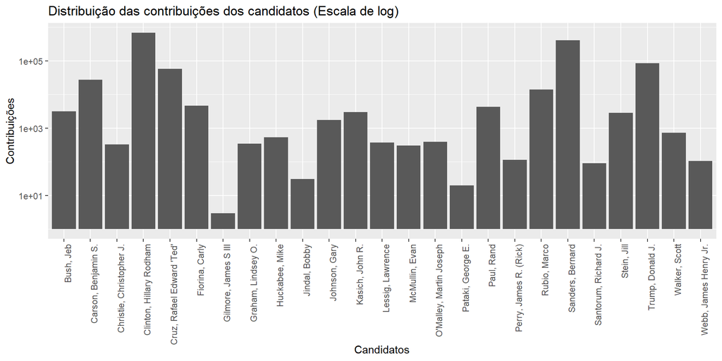

### Descrição 1

Para melhor compreender a distribuição das contribuições dos candidatos, o gráfico anterior mas usando escala de log, é possível perceber a disparidade entre as contribuições.

### Gráfico 2

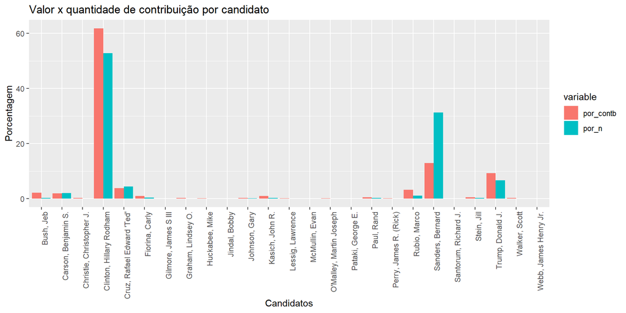

### Descrição 2

A diferença entre a quantidade de contribuição e o valor recebido, transformei os valores em porcentagem, assim podemos visualizar a representação de cada um. Em vermelho a porcentagem que o candidato tem em relação aos valores das contribuições e em azul a quantidade.

### Gráfico 3

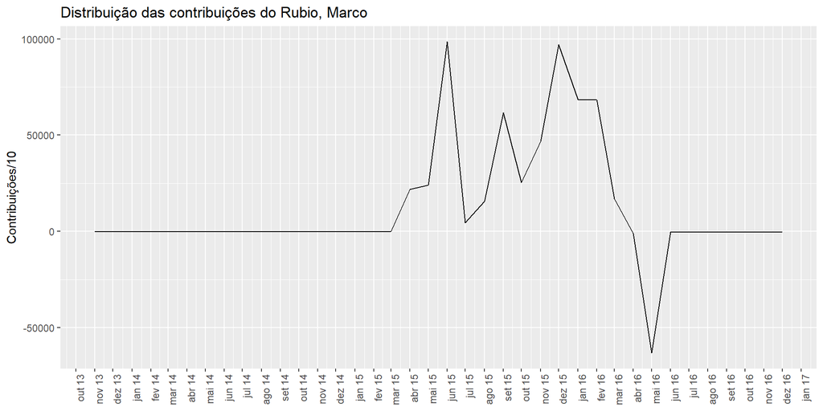

### Descrição 3

A Movimentação das contribuições do candidato Rubio, Marco, o candidato que mais recebeu contribuições($) negativas.

## Reflexão

O dataset possui aproximadamente 1300000 contribuições para candidatos a presidência, as contribuições foram realizadas no estado da Califórnia, o intervalo das contribuições é de nov/13 à dez/16, o dataset também possui informação sobre a ocupação do doador, algo que foi explorado durante a investigação, com foco nos doadores desempregados e aposentados. A presença de contribuições negativas também foi alvo das investigações do data set, especificamente o candidato Rubio, Marco que teve maior número de pedidos de reembolso. Um ponto de dificuldade do dataset é por possuir muitas variáveis categorias, tive um pouco de dificuldade para converter os valores em números e realizar o teste de correlação, que por sua vez, mostrou um resultado bem insatisfatório.